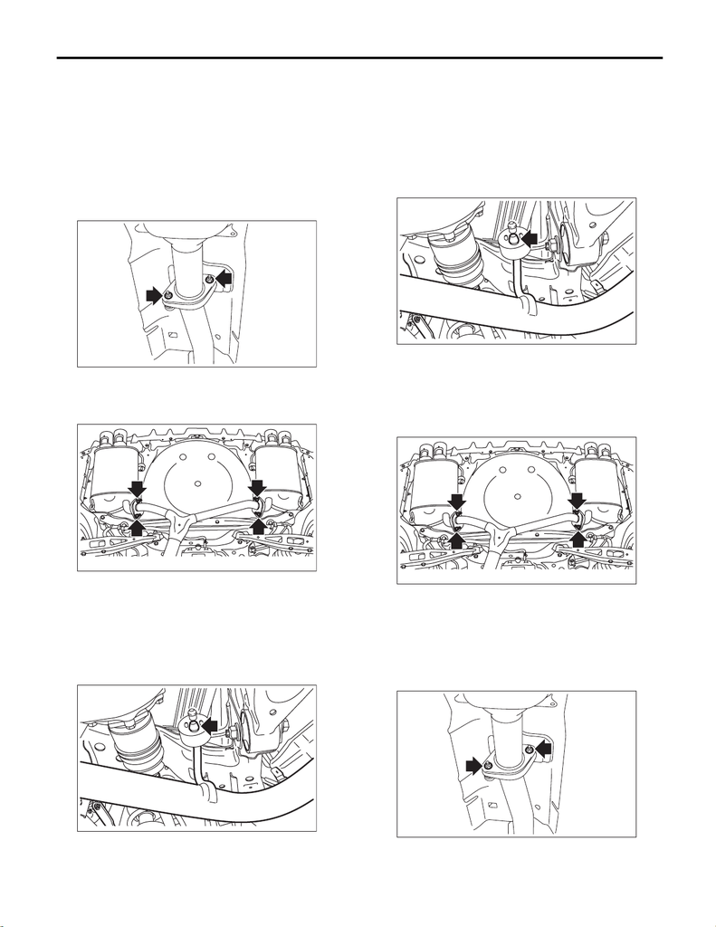

Rear Exhaust Pipe

EXHAUST

5. Rear Exhaust Pipe

A: REMOVAL

CAUTION:

Vehicle components are extremely hot after

driving. Be wary of receiving burns from heated

parts.

1) Lift up the vehicle.

2) Remove the center exhaust pipe from rear ex-

haust pipe.

3) Remove the muffler from rear exhaust pipe.

CAUTION:

Be careful not to drop the rear exhaust pipe.

4) Apply a coat of spray type lubricant to the mating

area of cushion rubber.

5) Remove the rear exhaust pipe from the cushion

rubber.

CAUTION:

Be careful not to let the muffler contact the rear

bumper.

B: INSTALLATION

1) Apply a coat of spray type lubricant to the mating

area of cushion rubber.

2) Install the rear exhaust pipe to cushion rubber.

NOTE:

After assembling, degrease the lubricant which

was applied to the cushion rubber while removing/

installing.

3) Install the rear exhaust pipe to the muffler.

NOTE:

Use a new gasket and self-locking nut.

Tightening torque:

48 N·m (4.9 kgf-m, 35.4 ft-lb)

4) Install the center exhaust pipe to rear exhaust

pipe.

NOTE:

Use a new gasket.

Tightening torque:

18 N·m (1.8 kgf-m, 13.3 ft-lb)

5) Lower the vehicle.

EX-03136

EX-03146

EX-03147

EX-03147

EX-03146

EX-03136

[figure not shown]

Rear Exhaust Pipe

EXHAUST

C: INSPECTION

1) Check the connections and welds for exhaust

leaks.

2) Make sure there are no holes or rusting.

3) Check the cushion rubber for wear or crack.